# Human Activity Recognition / Analysis

henfiber

## Goal

The goal is to predict how well 6 participants did barbell lifts using data from accelerometers on their belt, forearm, arm and dumbell. The participants were asked to perform barbell lifts correctly and incorrectly in 5 different ways. More information is available from the website here: http://groupware.les.inf.puc-rio.br/har (see the section on the Weight Lifting Exercise Dataset).

Thus, the goal is to train a model to predict which of the 5 different ways the exercise was performed.

## Data Reduction

The training and test sets contain summary statistics which have been removed for modelling purposes (most of the entries of these summary columns are NA). Additionally, the various non-numeric features, such as the user_name and timestamp have been removed as they are not useful for the model.

```r
# Load training and test sets
testing <- read.csv(unz("data/pml-testing.zip", "pml-testing.csv"))
training <- read.csv(unz("data/pml-training.zip", "pml-training.csv"))
```

```r
# Remove summary columns (avg, stddev, kurtosis, skewness, max, min, amplitude and var columns)
# Also remove non-numeric cols (user_name, X, time stamps and window cols)

removeCols <- grep("^kurt|^avg|^stddev|^var|^skewness|^max|^min|^amp|^total|timestamp|window|user_name", names(training))
removeCols <- c(removeCols, 1) # also remove the first id column
trainingSet <- training[,-removeCols]

removeCols <- grep("^kurt|^avg|^stddev|^var|^skewness|^max|^min|^amp|^total|timestamp|window|user_name", names(testing))
removeCols <- c(removeCols, 1) # also remove the first id column
testingSet <- testing[,-removeCols]
```

## Prediction Algorithm

The build the prediction model, we normalize the predictor variables (center and scale). Then we feed them into an SVM with radial basis functions and 10-fold cross-validation. Using SVM with cross-validation provides robust classification (We expect that the training error should be less that 10%)

```r
    # If the model has already been built, load it from disk
    if(file.exists("svm_model.rda")){
        load("svm_model.rda")
    } else {
        # Support vector machine fit with K-fold cross-validation
        K = 10   # 10-fold cross-validation
        set.seed(123)
        ctrl <- trainControl(method="cv",
                            number = K,
                            savePred=T)

        modFit <- train(classe ~ ., data=trainingSet,
                        method='svmRadial',
                        preProc=c("center", "scale"),
                        trControl = ctrl)
    }
```

The section below show the results of the prediction:

```
## Support Vector Machines with Radial Basis Function Kernel
##
## 19622 samples
##    48 predictor
##     5 classes: 'A', 'B', 'C', 'D', 'E'
##
## Pre-processing: centered, scaled
## Resampling: Cross-Validated (10 fold)
##
## Summary of sample sizes: 17660, 17661, 17659, 17660, 17658, 17660, ...
##
## Resampling results across tuning parameters:
##
##   C     Accuracy   Kappa      Accuracy SD  Kappa SD
##   0.25  0.8838551  0.8527093  0.008824797  0.011268436
##   0.50  0.9128533  0.8895178  0.006695677  0.008527803
##   1.00  0.9394050  0.9232264  0.006189299  0.007856380
##
## Tuning parameter 'sigma' was held constant at a value of 0.01563165
## Accuracy was used to select the optimal model using  the largest value.
## The final values used for the model were sigma = 0.01563165 and C = 1.
```

and the best final model:

```
## Support Vector Machine object of class "ksvm"
##
## SV type: C-svc  (classification)
##  parameter : cost C = 1
##
## Gaussian Radial Basis kernel function.
##  Hyperparameter : sigma =  0.015631646589294
##
## Number of Support Vectors : 8695
##
## Objective Function Value : -1330.838 -898.8193 -800.4689 -461.3715 -1239.918 -631.9876 -814.7021 -1312.223 -856.3727 -706.4695
## Training error : 0.053053
```

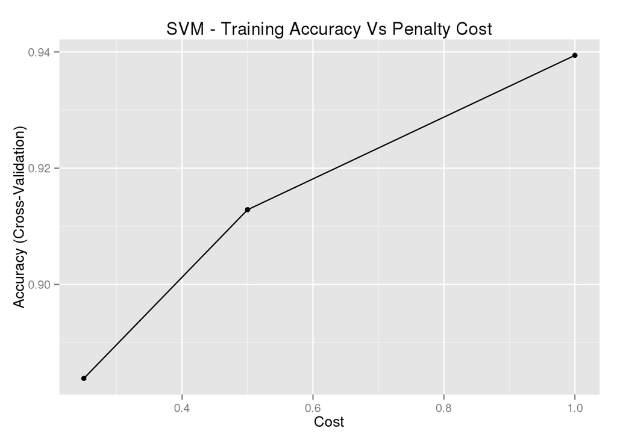